# Barbell Lifting Recognition

Andrey Yegorov

10/10/2020

### Introduction

To predict the manner in which a group of enthusiasts did the barbell lifting exercises - correctly and incorrectly in 5 different ways, personal activity measurements where collected from such devices as Jawbone Up, Nike FuelBand, and Fitbit. The goal of this report is to analyse these data and train the classifier for effective prediction of the activity type based on the provided measurements.

### Dependencies

Attach packages required for the analysis.

```r
library(caret)
library(dplyr)
library(randomForest)
```

Load the training data set.

```r
if (!file.exists('pml-training.csv')) {
        download.file('https://d396qusza40orc.cloudfront.net/predmachlearn/pml-training.csv',
                destfile='pml-training.csv', method='curl')
}
pmlData <- read.csv('pml-training.csv', na.strings=c("NA",""))
```

### Split the data

Let’s split our data into 3 sets:

- 50% - *training* - to train classifiers
- 20% - *testing* - to adjust parameters of classifiers and choose the best one
- 30% - *validation* - to evaluate the performance of the chosen classifier

```r
set.seed(20201010)
inBuild <- createDataPartition(pmlData$classe, p=.7, list=F)
validation <- pmlData[-inBuild,]
buildData <- pmlData[inBuild,]
inTrain <- createDataPartition(buildData$classe, p=.7, list=F)
training <- buildData[inTrain,]
testing <- buildData[-inTrain,]
c(training.count=nrow(training), testing.count=nrow(testing), validation.count=nrow(validation))
```

```
##   training.count    testing.count validation.count
##             9619             4118             5885
```

### Exploratory Data Analysis

High level overview of the training set.

```r
dim(training)
```

```
## [1] 9619  160
```

```r
table(training$classe)
```

```
##
##    A    B    C    D    E
## 2735 1861 1678 1577 1768
```

```r
table(is.na(training))
```

```
##
##  FALSE   TRUE
## 596940 942100
```

We may see near 10K observations with 1500-3000 observations per each class and more than one hundred variables and many NA values.

### Feature Selection

Machine learning algorithms are quite sensitive to NAs, so, select variables with less than 80% of NA values.

```r
tidytrain <- training
tidytrain <- tidytrain[, colMeans(is.na(tidytrain)) < 0.8]
```

Number of NAs in selected variables: 0.

As we have quite a lot of variable we may drop ones with near-zero variance to avoid overfitting.

```r
tidytrain <- tidytrain[, -nearZeroVar(training)]
```

Remove several more out of interest variables - row number, user name, time windows and stamps.

```r
tidytrain <- tidytrain %>%
        select(-c('X', 'user_name', 'num_window'), -matches('timestamp'))
```

Set correct types for the remaining variables.

```r
tidytrain$classe <- factor(training$classe)
```

### Model Training

Categorical output and many numeric variables makes ensemble of decision trees a reasonable choice.  
Several gradient boosting machines and random forests with different settings were trained.  
Based on prediction accuracy on test set and speed of training, random forest of 10 trees was chosen.

```r
forest <- randomForest(formula=classe ~ ., ntree=10, data=tidytrain)
confusionMatrix(predict(forest, testing), factor(testing$classe))
```

```
## Confusion Matrix and Statistics
##
##           Reference
## Prediction    A    B    C    D    E
##          A 1161   14    1    2    0
##          B    5  769   13    1    0
##          C    1   13  702   10    7
##          D    3    0    1  661    7
##          E    1    1    1    1  743
##
## Overall Statistics
##
##                Accuracy : 0.9801
##                  95% CI : (0.9753, 0.9841)
##     No Information Rate : 0.2844
##     P-Value [Acc > NIR] : < 2.2e-16
##
##                   Kappa : 0.9748
##
##  Mcnemar's Test P-Value : 0.008074
##
## Statistics by Class:
##
##                      Class: A Class: B Class: C Class: D Class: E
## Sensitivity            0.9915   0.9649   0.9777   0.9793   0.9815
## Specificity            0.9942   0.9943   0.9909   0.9968   0.9988
## Pos Pred Value         0.9856   0.9759   0.9577   0.9836   0.9946
## Neg Pred Value         0.9966   0.9916   0.9953   0.9959   0.9958
## Prevalence             0.2844   0.1935   0.1744   0.1639   0.1838
## Detection Rate         0.2819   0.1867   0.1705   0.1605   0.1804
## Detection Prevalence   0.2861   0.1914   0.1780   0.1632   0.1814
## Balanced Accuracy      0.9928   0.9796   0.9843   0.9880   0.9902
```

Benefit of random forest is interpretability. The following plot shows how important each feature in predicting *classe* outcome.

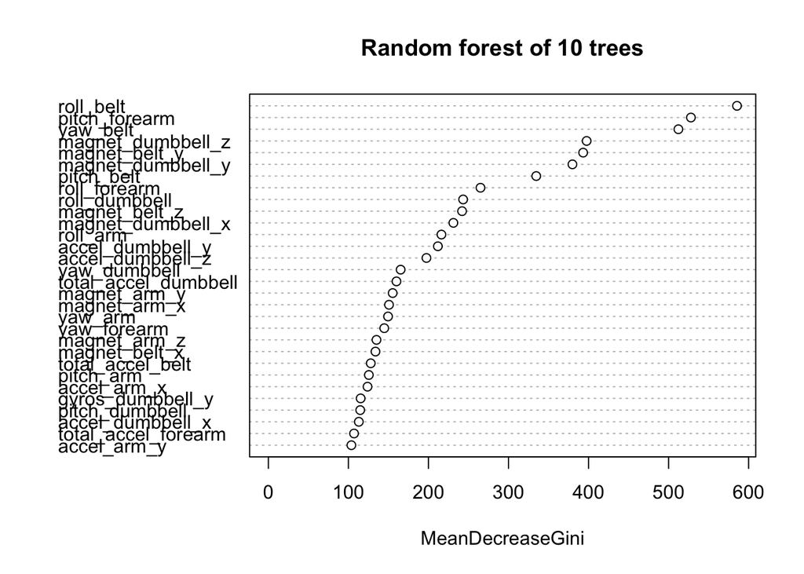

```r
varImpPlot(forest, main='Random forest of 10 trees')
```

### Model Estimation

To estimate out-of sample error, we need to use independent set which was not used during model training, tuning and model selection - validation set.

```r
confusionMatrix(predict(forest, validation), factor(validation$classe))
```

```
## Confusion Matrix and Statistics
##
##           Reference
## Prediction    A    B    C    D    E
##          A 1661   16    1    3    1
##          B    3 1109   16    4    9
##          C    5    9  999   14    8
##          D    4    2    9  939    6
##          E    1    3    1    4 1058
##
## Overall Statistics
##
##                Accuracy : 0.9798
##                  95% CI : (0.9759, 0.9832)
##     No Information Rate : 0.2845
##     P-Value [Acc > NIR] : < 2.2e-16
##
##                   Kappa : 0.9744
##
##  Mcnemar's Test P-Value : 0.006934
##
## Statistics by Class:
##
##                      Class: A Class: B Class: C Class: D Class: E
## Sensitivity            0.9922   0.9737   0.9737   0.9741   0.9778
## Specificity            0.9950   0.9933   0.9926   0.9957   0.9981
## Pos Pred Value         0.9875   0.9720   0.9652   0.9781   0.9916
## Neg Pred Value         0.9969   0.9937   0.9944   0.9949   0.9950
## Prevalence             0.2845   0.1935   0.1743   0.1638   0.1839
## Detection Rate         0.2822   0.1884   0.1698   0.1596   0.1798
## Detection Prevalence   0.2858   0.1939   0.1759   0.1631   0.1813
## Balanced Accuracy      0.9936   0.9835   0.9831   0.9849   0.9880
```

The expected accuracy of our fitted random forest with 10 trees is more than 97% for each class.

### Conclusion

For classification with many variables, ensemble of non-linear methods, such as GBM and random forests, can show quite high accuracy and good interpretability of classification results.